# Modulo 7 - Prima serie

Soluzioni

Author

Ottavia Epifania

# 1 Introduzione

In questa serie di esercizi si rianalizzano i dati del Laboratorio del Modulo didattico 3 (Abilità spazio-simboliche in età infantile: 3-4 anni), contenuti nel file `DataAS.csv`, con i modelli di regressione visti nel Modulo 7. Fare riferimento al testo del laboratorio del Modulo 3 per la descrizione delle variabili.

# 2 Esercizi

Tutte le analisi inferenziali devono essere precedute da opportune rappresentazioni grafiche.

## 2.1

Importare il file `DataAS.csv` e assegnarlo alla variabile `dati`.

```r
dati = read.csv2("DataAS.csv")
head(dati)
```

```
  Sgg S  E a1b1 a1b2 a2b1 a2b2
1   1 f 37    6    4    7    6
2   2 f 38    5    3    8    5
3   3 f 36    5    2    6    7
4   4 f 36    6    3    6    8
5   5 f 39    7    2    5    8
6   6 f 39    4    4    6    6
```

```r
str(dati)
```

```
'data.frame':   60 obs. of  7 variables:
 $ Sgg : int  1 2 3 4 5 6 7 8 9 10 ...
 $ S   : chr  "f" "f" "f" "f" ...
 $ E   : int  37 38 36 36 39 39 40 41 36 36 ...
 $ a1b1: int  6 5 5 6 7 4 5 6 6 7 ...
 $ a1b2: int  4 3 2 3 2 4 5 3 2 4 ...
 $ a2b1: int  7 8 6 6 5 6 7 5 6 5 ...
 $ a2b2: int  6 5 7 8 8 6 7 8 6 7 ...
```

## 2.2

A partire dal data frame `dati`, creare due nuove variabili:

- `a1`: per ogni bambino/a, la somma dei valori sulle variabili `a1b1` e `a1b2` (scenario macchinine)
- `a2`: per ogni bambino/a, la somma dei valori sulle variabili `a2b1` e `a2b2` (scenario casa delle bambole)

```r
dati$a1 = dati$a1b1 + dati$a1b2
dati$a2 = dati$a2b1 + dati$a2b2
```

## 2.3

Studiare, con due modelli di regressione separati:

1. la relazione tra la variabile dipendente `a1` e la variabile indipendente `E`;
2. la relazione tra la variabile dipendente `a2` e la variabile indipendente `E`.

Per ciascun modello, rappresentare graficamente la relazione tra le variabili, riportare i risultati statisticamente significativi e indicare il tipo di relazione lineare che lega la variabile indipendente alla variabile dipendente.

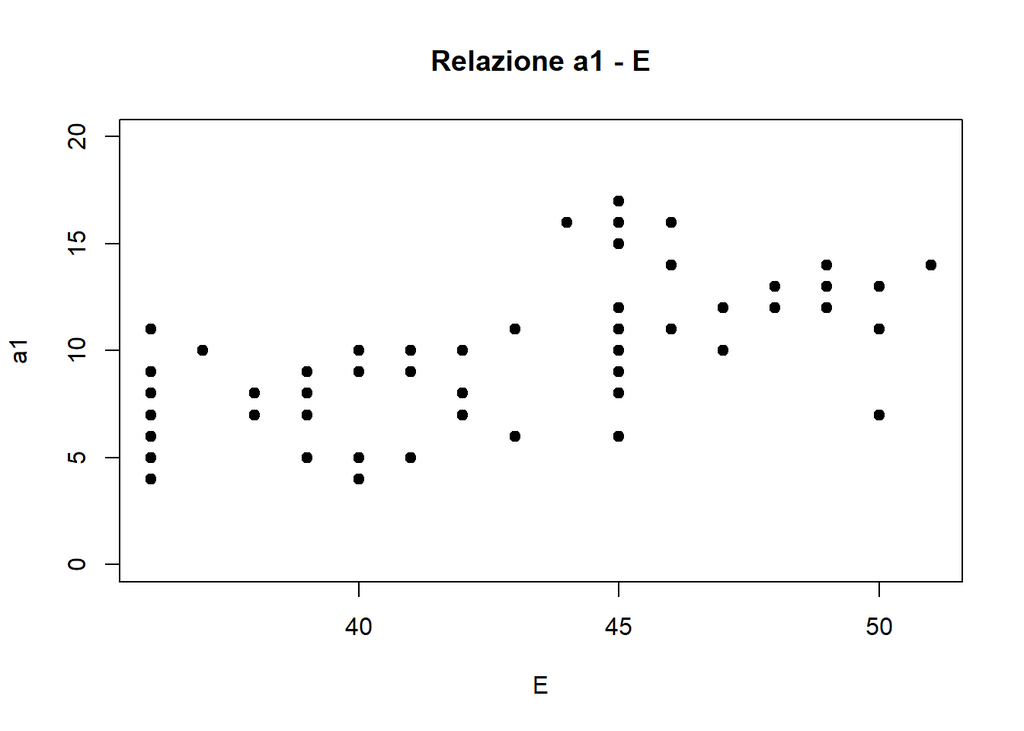

```r
plot(dati$E, dati$a1, pch = 19, main = "Relazione a1 - E",
     xlab = "E", ylab = "a1", ylim = c(0, 20))
```

```
Il grafico suggerisce una relazione positiva tra E e a1
```

```r
ma1 = lm(a1 ~ E, data = dati)
summary(ma1)
```

```
Call:
lm(formula = a1 ~ E, data = dati)

Residuals:
    Min      1Q  Median      3Q     Max
-6.3965 -1.7887 -0.0616  1.0622  5.8971

Coefficients:
            Estimate Std. Error t value Pr(>|t|)
(Intercept) -9.53928    3.52647  -2.705  0.00895 **
E            0.45872    0.08185   5.604 6.06e-07 ***
---
Signif. codes:  0 '***' 0.001 '**' 0.01 '*' 0.05 '.' 0.1 ' ' 1

Residual standard error: 2.842 on 58 degrees of freedom
Multiple R-squared:  0.3513,    Adjusted R-squared:  0.3401
F-statistic: 31.41 on 1 and 58 DF,  p-value: 6.062e-07
```

```
Entrambi i parametri sono statisticamente significativi (alpha = .05).
Il coefficiente angolare è positivo: all'aumentare dell'età aumenta in media il punteggio a1
```

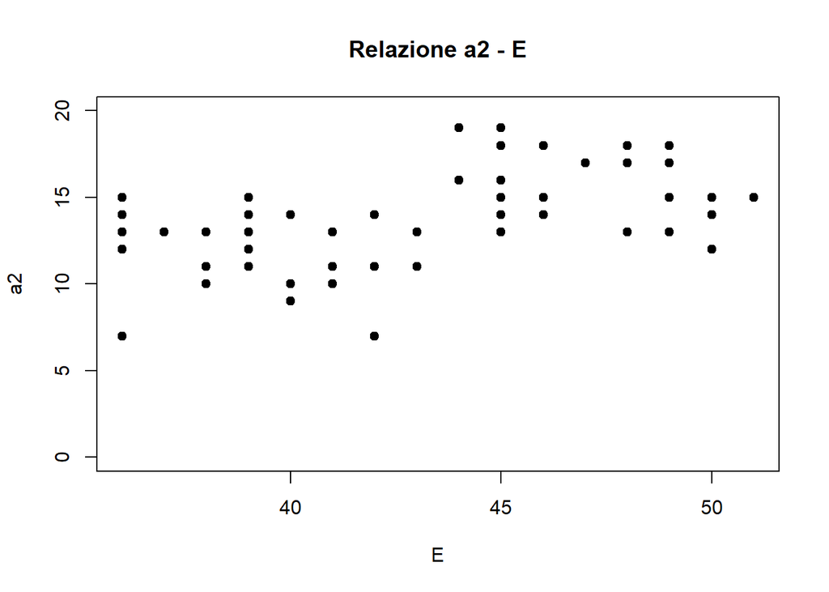

```r
plot(dati$E, dati$a2, pch = 19, main = "Relazione a2 - E",
     xlab = "E", ylab = "a2", ylim = c(0, 20))
```

```
Il grafico suggerisce una relazione positiva tra E e a2
```

```r
ma2 = lm(a2 ~ E, data = dati)
summary(ma2)
```

```
Call:
lm(formula = a2 ~ E, data = dati)

Residuals:
    Min      1Q  Median      3Q     Max
-6.3247 -1.6622  0.1307  1.6307  4.9492

Coefficients:
            Estimate Std. Error t value Pr(>|t|)
(Intercept)  -1.9230     2.9553  -0.651    0.518
E             0.3630     0.0686   5.293 1.93e-06 ***
---
Signif. codes:  0 '***' 0.001 '**' 0.01 '*' 0.05 '.' 0.1 ' ' 1

Residual standard error: 2.382 on 58 degrees of freedom
Multiple R-squared:  0.3257,    Adjusted R-squared:  0.314
F-statistic: 28.01 on 1 and 58 DF,  p-value: 1.93e-06
```

```
Solo il coefficiente angolare è statisticamente significativo (alpha = .05):
la relazione tra E e a2 è positiva. L'intercetta non è diversa da 0
```

## 2.4

Calcolare gli intervalli di confidenza al 95% per i parametri dei due modelli. Confrontare le conclusioni basate sugli intervalli di confidenza con quelle basate sul confronto tra $p$-value e $\alpha = .05$.

```r
# modello con a1 come variabile dipendente
coefsA1 = data.frame(summary(ma1)$coefficients)
qt95 = qt(.975, ma1$df.residual)
deltaA1 = coefsA1$Std..Error * qt95
data.frame(limInf = coefsA1$Estimate - deltaA1,
           limSup = coefsA1$Estimate + deltaA1,
           row.names = rownames(coefsA1))
```

```
                 limInf     limSup
(Intercept) -16.5982785 -2.4802822
E             0.2948719  0.6225585
```

```r
# modello con a2 come variabile dipendente
coefsA2 = data.frame(summary(ma2)$coefficients)
deltaA2 = coefsA2$Std..Error * qt95
data.frame(limInf = coefsA2$Estimate - deltaA2,
           limSup = coefsA2$Estimate + deltaA2,
           row.names = rownames(coefsA2))
```

```
                limInf    limSup
(Intercept) -7.8387197 3.9927997
E            0.2257326 0.5003488
```

```r
# confronto con la funzione confint()
confint(ma1)
```

```
                  2.5 %     97.5 %
(Intercept) -16.5982785 -2.4802822
E             0.2948719  0.6225585
```

```r
confint(ma2)
```

```
                 2.5 %    97.5 %
(Intercept) -7.8387197 3.9927997
E            0.2257326 0.5003488
```

```
Modello a1: nessun intervallo contiene lo 0, entrambi i parametri sono significativi.
Modello a2: l'intervallo dell'intercetta contiene lo 0 (non significativa),
quello del coefficiente angolare no (significativo).
Le conclusioni sono le stesse dei test sui coefficienti
```

## 2.5

Valutare i residui dei due modelli con almeno due rappresentazioni grafiche ciascuno.

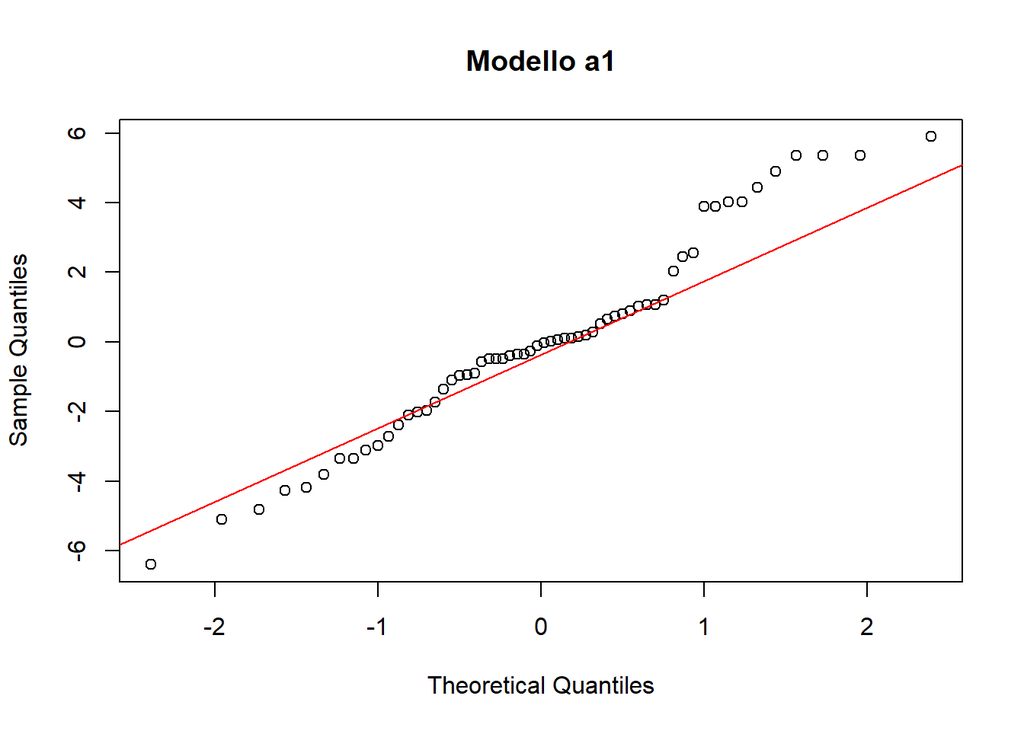

```r
qqnorm(ma1$residuals, main = "Modello a1")
qqline(ma1$residuals, col = "red")
```

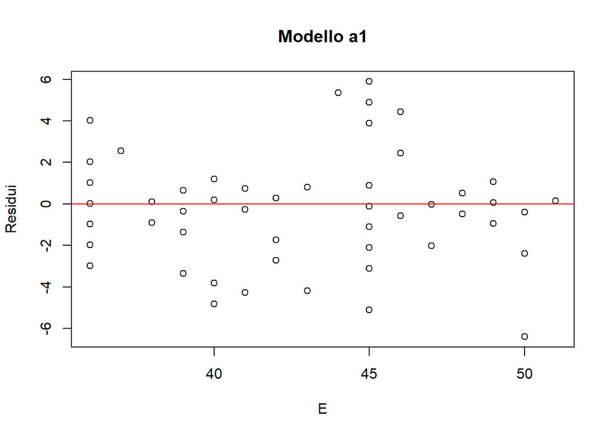

```r
plot(dati$E, ma1$residuals, xlab = "E", ylab = "Residui", main = "Modello a1")
abline(h = 0, col = "red")
```

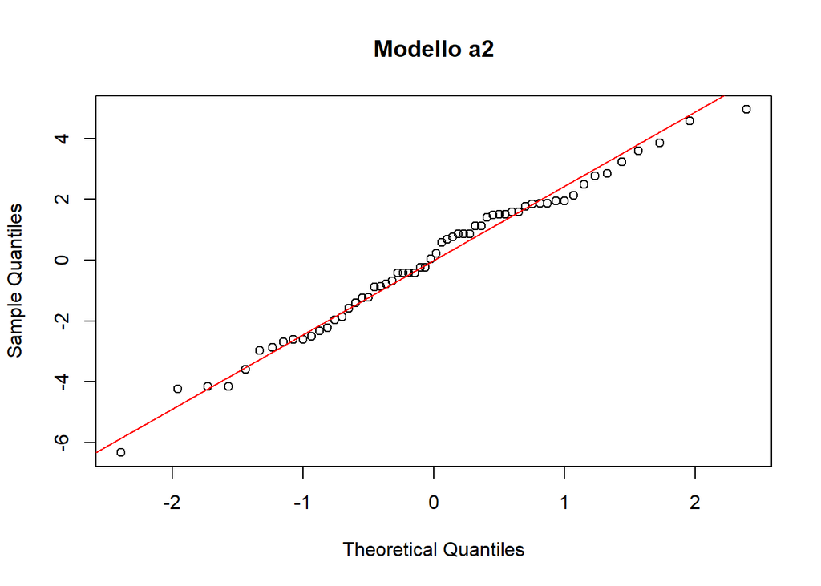

```r
qqnorm(ma2$residuals, main = "Modello a2")
qqline(ma2$residuals, col = "red")
```

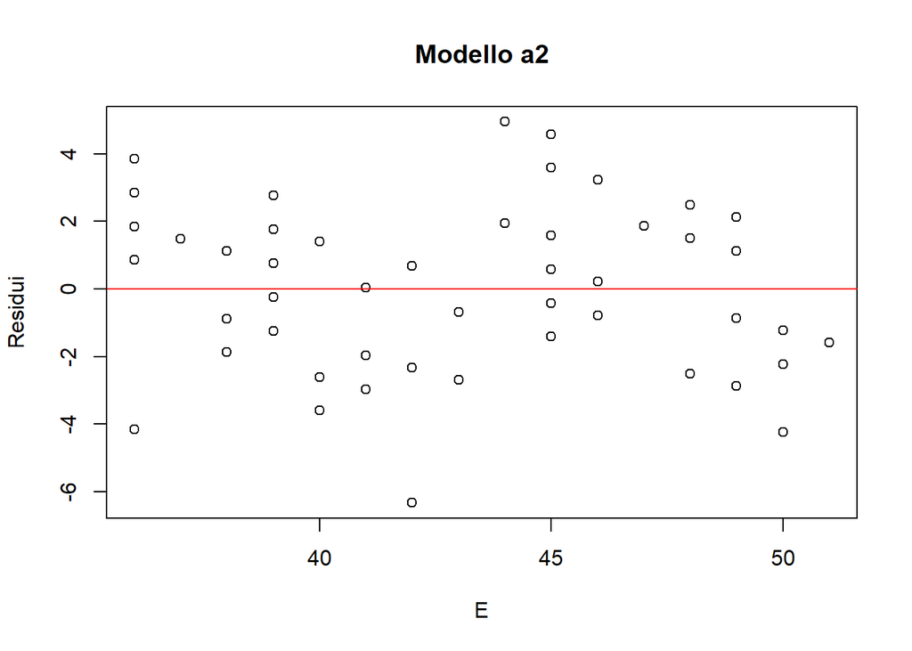

```r
plot(dati$E, ma2$residuals, xlab = "E", ylab = "Residui", main = "Modello a2")
abline(h = 0, col = "red")
```

## 2.6

Ripetere le analisi dell’esercizio 3 includendo nei modelli anche la variabile di classificazione `S`. Partire da un modello parallelo e proseguire con un modello con interazione. Per ogni modello, rappresentare le rette di regressione dei due gruppi.

### 2.6.1 Variabile dipendente `a1`

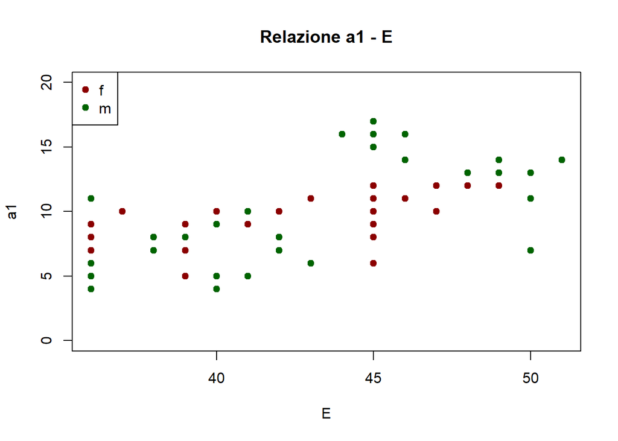

```r
plot(dati$E, dati$a1, pch = 19, main = "Relazione a1 - E",
     xlab = "E", ylab = "a1", ylim = c(0, 20),
     col = ifelse(dati$S == "f", "darkred", "darkgreen"))
legend("topleft", pch = 19, col = c("darkred", "darkgreen"),
       legend = c("f", "m"))
```

```
Dal grafico non sembra che i due gruppi si distinguano
```

```r
ma1S = lm(a1 ~ E + S, data = dati)
summary(ma1S)
```

```
Call:
lm(formula = a1 ~ E + S, data = dati)

Residuals:
    Min      1Q  Median      3Q     Max
-6.5951 -1.8087 -0.0904  1.2444  5.6829

Coefficients:
            Estimate Std. Error t value Pr(>|t|)
(Intercept) -9.62672    3.54920  -2.712  0.00882 **
E            0.45560    0.08247   5.524 8.53e-07 ***
Sm           0.44183    0.73940   0.598  0.55251
---
Signif. codes:  0 '***' 0.001 '**' 0.01 '*' 0.05 '.' 0.1 ' ' 1

Residual standard error: 2.858 on 57 degrees of freedom
Multiple R-squared:  0.3553,    Adjusted R-squared:  0.3327
F-statistic: 15.71 on 2 and 57 DF,  p-value: 3.683e-06
```

```
Intercetta e coefficiente di E sono significativi, il coefficiente di S no:
a parità di età non ci sono differenze tra i due gruppi nel punteggio a1
```

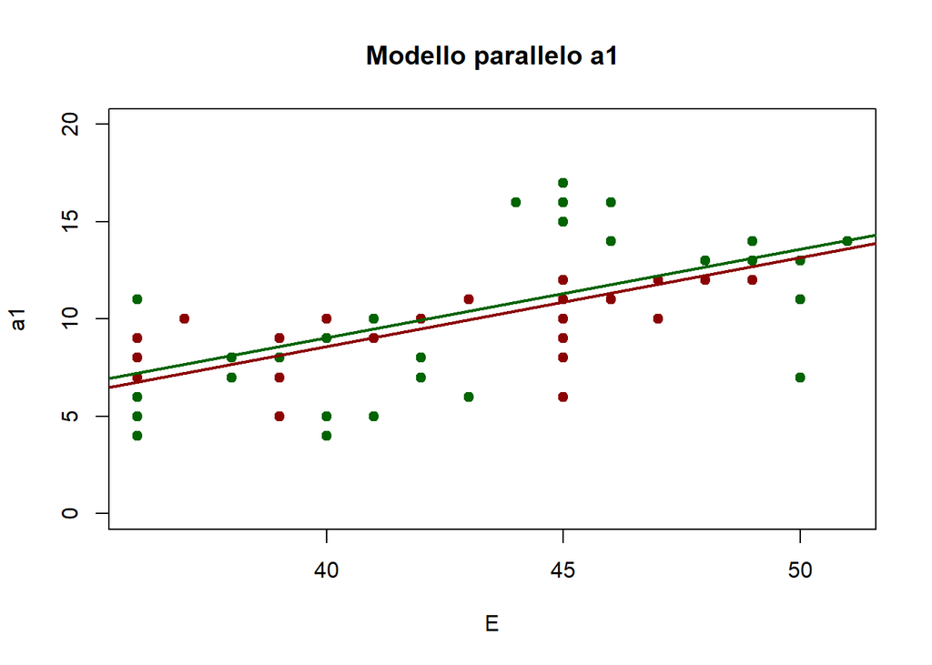

```r
coefa1 = coef(ma1S)
plot(dati$E, dati$a1, pch = 19, main = "Modello parallelo a1",
     xlab = "E", ylab = "a1", ylim = c(0, 20),
     col = ifelse(dati$S == "f", "darkred", "darkgreen"))
abline(coefa1[1], coefa1[2], col = "darkred", lwd = 2) # gruppo f
abline(coefa1[1] + coefa1[3], coefa1[2], col = "darkgreen", lwd = 2) # gruppo m
```

```r
ma1Sinter = lm(a1 ~ E * S, data = dati)
summary(ma1Sinter)
```

```
Call:
lm(formula = a1 ~ E * S, data = dati)

Residuals:
    Min      1Q  Median      3Q     Max
-7.3338 -1.4813  0.0903  1.1719  5.4821

Coefficients:
            Estimate Std. Error t value Pr(>|t|)
(Intercept)  -4.4104     5.1176  -0.862   0.3925
E             0.3331     0.1196   2.785   0.0073 **
Sm           -9.4146     7.0586  -1.334   0.1877
E:Sm          0.2301     0.1639   1.404   0.1658
---
Signif. codes:  0 '***' 0.001 '**' 0.01 '*' 0.05 '.' 0.1 ' ' 1

Residual standard error: 2.834 on 56 degrees of freedom
Multiple R-squared:  0.3772,    Adjusted R-squared:  0.3439
F-statistic: 11.31 on 3 and 56 DF,  p-value: 6.651e-06
```

```
Solo il coefficiente di E è significativo: l'interazione non lo è,
quindi non ci sono evidenze che la relazione tra età e a1 sia diversa nei due gruppi
```

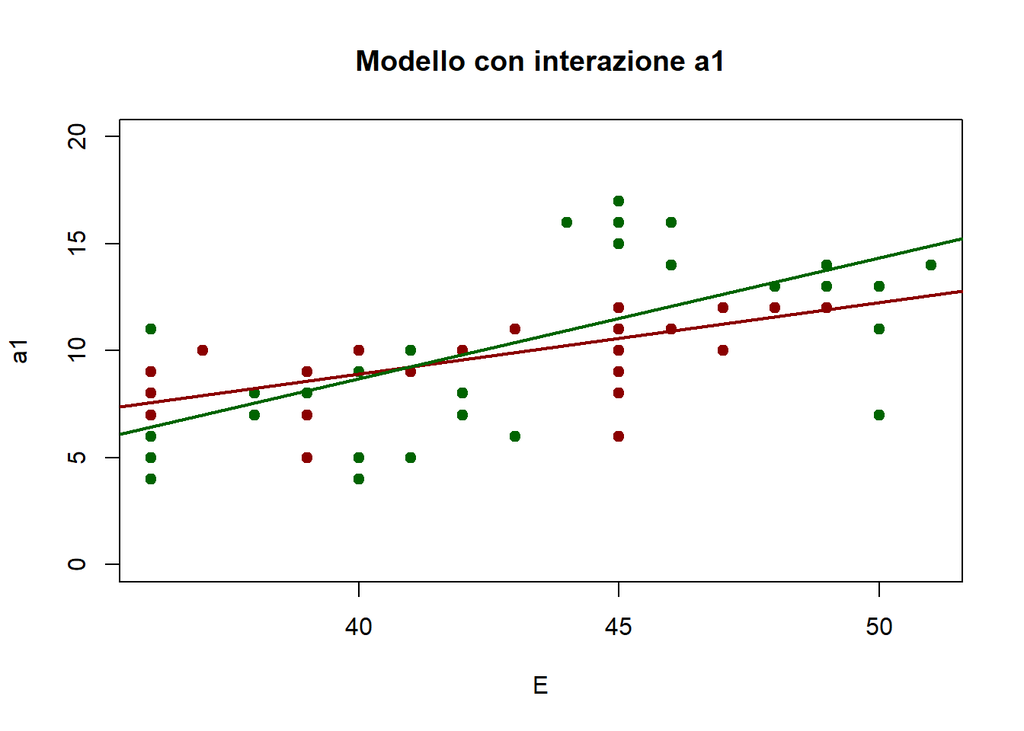

```r
coefa1inter = coef(ma1Sinter)
plot(dati$E, dati$a1, pch = 19, main = "Modello con interazione a1",
     xlab = "E", ylab = "a1", ylim = c(0, 20),
     col = ifelse(dati$S == "f", "darkred", "darkgreen"))
abline(coefa1inter[1], coefa1inter[2], col = "darkred", lwd = 2) # gruppo f
abline(coefa1inter[1] + coefa1inter[3], coefa1inter[2] + coefa1inter[4],
       col = "darkgreen", lwd = 2) # gruppo m
```

```
Anche se nel grafico le rette non sono parallele,
la differenza tra i coefficienti angolari non è significativa
```

### 2.6.2 Variabile dipendente `a2`

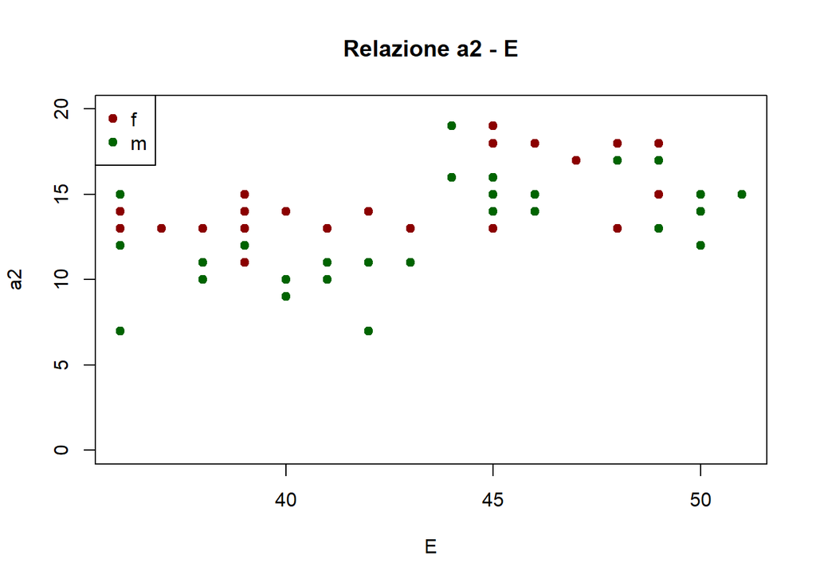

```r
plot(dati$E, dati$a2, pch = 19, main = "Relazione a2 - E",
     xlab = "E", ylab = "a2", ylim = c(0, 20),
     col = ifelse(dati$S == "f", "darkred", "darkgreen"))
legend("topleft", pch = 19, col = c("darkred", "darkgreen"),
       legend = c("f", "m"))
```

```r
ma2S = lm(a2 ~ E + S, data = dati)
summary(ma2S)
```

```
Call:
lm(formula = a2 ~ E + S, data = dati)

Residuals:
    Min      1Q  Median      3Q     Max
-5.2719 -1.4934  0.0359  1.2582  5.9727

Coefficients:
            Estimate Std. Error t value Pr(>|t|)
(Intercept) -1.51119    2.67439  -0.565 0.574252
E            0.37771    0.06215   6.078 1.07e-07 ***
Sm          -2.08070    0.55715  -3.735 0.000437 ***
---
Signif. codes:  0 '***' 0.001 '**' 0.01 '*' 0.05 '.' 0.1 ' ' 1

Residual standard error: 2.154 on 57 degrees of freedom
Multiple R-squared:  0.4582,    Adjusted R-squared:  0.4392
F-statistic:  24.1 on 2 and 57 DF,  p-value: 2.593e-08
```

```
Il coefficiente di E e quello di S sono significativi.
A parità di età, il gruppo m ha in media un punteggio a2 più basso del gruppo f
```

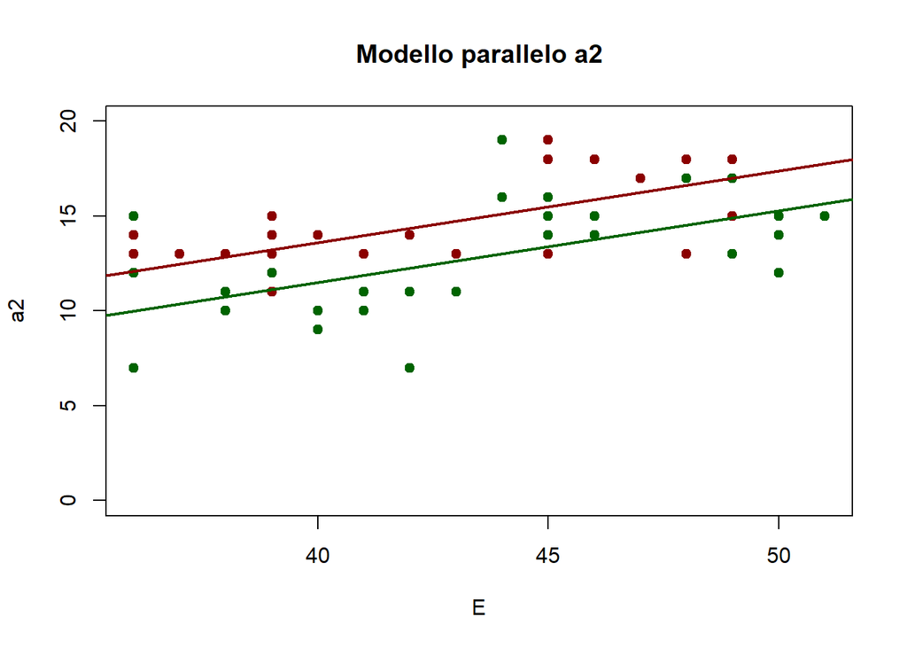

```r
coefa2 = coef(ma2S)
plot(dati$E, dati$a2, pch = 19, main = "Modello parallelo a2",
     xlab = "E", ylab = "a2", ylim = c(0, 20),
     col = ifelse(dati$S == "f", "darkred", "darkgreen"))
abline(coefa2[1], coefa2[2], col = "darkred", lwd = 2) # gruppo f
abline(coefa2[1] + coefa2[3], coefa2[2], col = "darkgreen", lwd = 2) # gruppo m
```

```r
ma2Sinter = lm(a2 ~ E * S, data = dati)
summary(ma2Sinter)
```

```
Call:
lm(formula = a2 ~ E * S, data = dati)

Residuals:
   Min     1Q Median     3Q    Max
-5.235 -1.415 -0.169  1.314  5.945

Coefficients:
            Estimate Std. Error t value Pr(>|t|)
(Intercept)  0.05593    3.91288   0.014 0.988645
E            0.34089    0.09145   3.728 0.000452 ***
Sm          -5.04186    5.39694  -0.934 0.354208
E:Sm         0.06913    0.12532   0.552 0.583378
---
Signif. codes:  0 '***' 0.001 '**' 0.01 '*' 0.05 '.' 0.1 ' ' 1

Residual standard error: 2.167 on 56 degrees of freedom
Multiple R-squared:  0.4612,    Adjusted R-squared:  0.4323
F-statistic: 15.98 on 3 and 56 DF,  p-value: 1.268e-07
```

```
Solo il coefficiente di E è significativo. L'interazione non è significativa:
la relazione tra età e a2 non è diversa nei due gruppi, quindi il modello parallelo è sufficiente.
Nel modello con interazione il coefficiente di S non è più significativo perché
rappresenta la differenza tra i gruppi quando E = 0
```

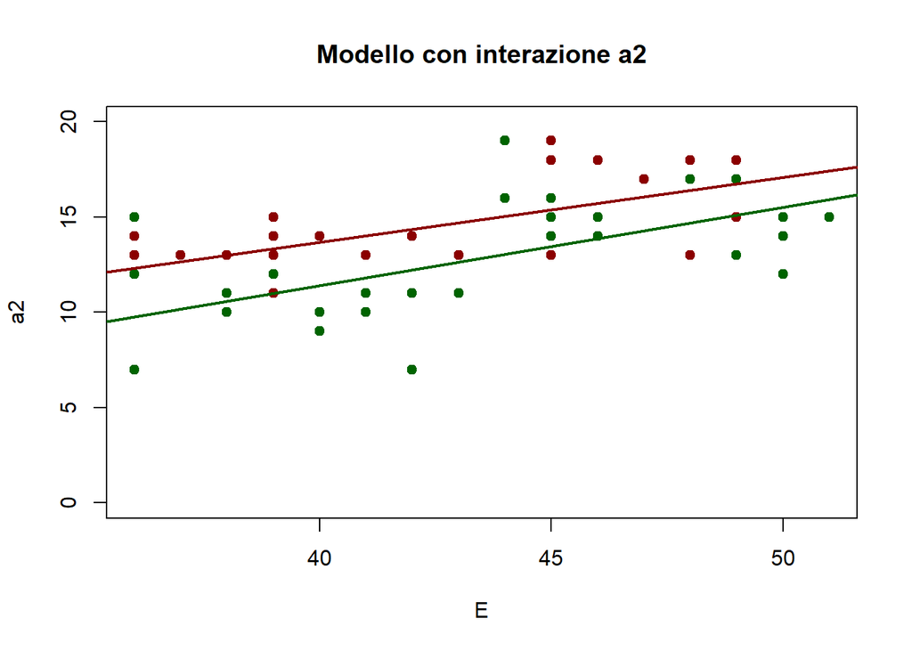

```r
coefa2inter = coef(ma2Sinter)
plot(dati$E, dati$a2, pch = 19, main = "Modello con interazione a2",
     xlab = "E", ylab = "a2", ylim = c(0, 20),
     col = ifelse(dati$S == "f", "darkred", "darkgreen"))
abline(coefa2inter[1], coefa2inter[2], col = "darkred", lwd = 2) # gruppo f
abline(coefa2inter[1] + coefa2inter[3], coefa2inter[2] + coefa2inter[4],
       col = "darkgreen", lwd = 2) # gruppo m
```

## 2.7

Per il modello parallelo con variabile dipendente `a2`, calcolare gli intervalli di confidenza al 95% per i parametri.

```r
confint(ma2S)
```

```
                 2.5 %     97.5 %
(Intercept) -6.8665674  3.8441959
E            0.2532654  0.5021545
Sm          -3.1963856 -0.9650190
```

```
Gli intervalli dei coefficienti di E e di S non contengono lo 0,
quello dell'intercetta sì
```